# Méthode de la tangente dit méthode d'Euler

Concentrons-nous sur les problèmes de Cauchy, *ie* sur les problèmes de valeur initiale du premier ordre : $$\frac{dy}{dt} = f(t,y)$$ et de la condition initiale $$y(t_0) = y_0.$$

On suppose pour plus de simplicité que les fonctions $f$ et $f_y$ sont continues dans un rectangle dans le plan $ty$ contenant le point $(t_0,y_0)$ ; le théorème de Cauchy-Lipschitz nous assure l'existence et l'unicité d'une solution $y = \phi(t)$ au problème de cauchy dans un intervalle autour de $t_0$.

**Théorème :** *Si les fonctions $f$ et $\partial f/\partial y$ sont continues dans un rectangle $\alpha < t <\beta$, $\gamma < y < \delta$ contenant le point $(t_0,y_0)$, alors il existe un intervalle $t_0 - h < t < t_0+h$ contenu dans $\alpha < t < \beta$ pour lequel il existe une solution unique $y = \phi(t)$ concernant le problème de valeur initiale : $y'=f(t,y),~ y(t_0) = y_0.$*

On a pu voir que tracer un champ de direction était simple et efficace, cependant ça a ses limites ; cette démarche ne se prête pas aux comparaisons ou aux calculs quantitatifs, ce qui est un défaut de première importance.

Une autre possibilité consisterai à calculer des valeurs approximatives de la solution $y = \phi(t)$ au problème de Cauchy pour un ensemble choisi de valeurs de $t$.

Parlons ici d'une méthode qui fera ce boulot :

### Rappel : Tangente

Si $f$ est une fonction dérivable sur un intervalle contenant un réel $a$, la tangente à la courbe représentative de $f$ au point d’abscisse $a$ a pour équation : $$y = f(a) + f'(a)(x-a)$$

### Méthode des tangentes :

- Comment pourrait-on calculer l'approximation de la solution $y = \phi(t)$ à l'équation $\frac{dy}{dt} = f(t,y)$ près de $t = t_0$.
  > - On sait que la solution passe par le point initial $(t_0,y_0)$ et, à partir de l'ED, on sait aussi que sa pente en ce point est $f(t_0,y_0)$.
  > - On peut donc trouver l'équation de la droite tangente à la courbe-solution en $(t_0,y_0)$ : $$y = y_0 + f(t_0,y_0)(t - t_0).$$

La droite tangente est une bonne approximation de la courbe-solution dans un intervalle de temps suffisamment petit, à condition que la pente d la solution ne change pas de façon significative de sa valeur au point initial.

Ainsi si $t_1$ est suffisamment ptoche de $t_0$, on peut calculer l'approximation de $\phi(t_1)$ par la valeur $y_1$ déterminée en posant $t = t_1$ dans l'équation de la droite tangente en $t = t_0$.

On a alors : $$y_1 = y_0 + f(t_0,y_0)(t_1-t_0).$$

# Exemple pour l'ED $y' = 3-2y$ passant en $(0,2)$ :

On a donc $y'=f(t,y)$

Pour la première tangente on a : $y = 2 + t ~f(0,2)$

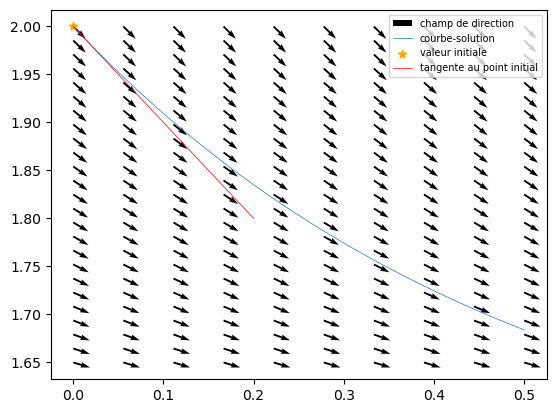

```python
import matplotlib.pyplot as plt
import numpy as np



y = lambda t : 3/2 +1/2*np.exp(-2*t)
y_prime = lambda y : 3-2*y
tang_1 = lambda t : 2 + y_prime(2)*t

t = np.linspace(0,.5,100)
t_ = np.linspace(0,.2,2)

tt = np.linspace(0,0.5,10)
yy = np.linspace(1.65,2,25)

TT, YY = np.meshgrid(tt,yy)

dt, dy = 1, y_prime(YY)
N = np.hypot(dt,dy)


plt.quiver(TT,YY, dt/N, dy/N, label = "champ de direction")
plt.plot(t, y(t), label = "courbe-solution", linewidth=0.5)
plt.scatter(0,2, marker = "*", color = "orange", label = "valeur initiale")
plt.plot(t_, tang_1(t_), label = "tangente au point initial",linewidth=0.5, color = 'red')
plt.legend(fontsize = 7, loc = "upper right")
plt.show()
```

On ne suppose pas connue la fonction solution, pour calculer une valeur approchée de la solution au temps $t_1$ on utilise l'expression de la tangente au point $t = t_0$ :

On a ainsi une nouvelle tangente : $$y = y_1 + f(t_1,y_1)(t - t_1).$$

En itérant le procédé :

```python
T = np.linspace(0,1, 10)
Y = np.empty(len(T))
t = np.linspace(0,1, 100)

y_0 = 2
Y[0] = 2
```

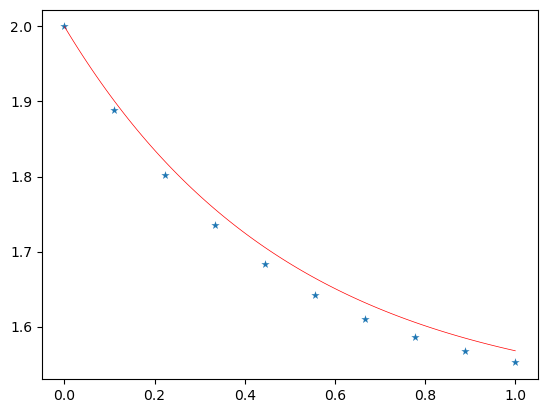

```python
for i in range(len(T)-1):
    Y[i+1] = Y[i] + y_prime(Y[i])*(T[i+1]-T[i])

plt.scatter(T, Y,marker = "*",linewidths=0.05)
plt.plot(t, y(t), label = "courbe-solution", linewidth=0.5, color = "red")

plt.show()
```

# Exemple avec l'ED : $y' = 3 + e^{-t} - \frac{y}{2}, ~ y(0) = 1$

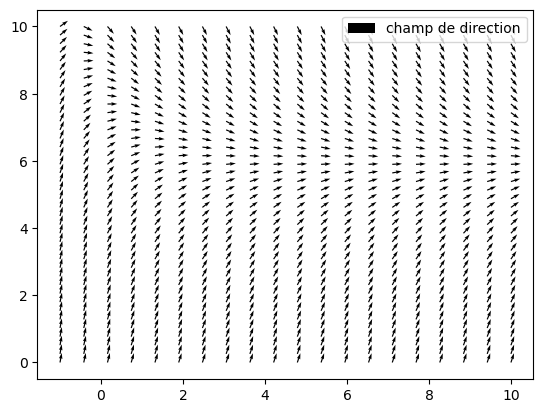

```python
#commençons par représenter le champ de direction :

t = np.linspace(-1,10,20)

y = np.linspace(0,10,40)

tt, yy = np.meshgrid(t,y)

y_prime = lambda t,y : 3 + np.exp(-t) - y/2

dt, dy = 1, y_prime(tt,yy)

N = np.hypot(dt, dy)

plt.quiver(tt, yy, dt/N, dy/N, label = "champ de direction")
plt.legend()
plt.show()
```

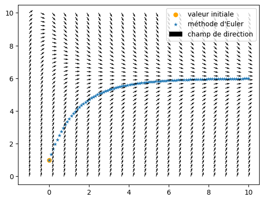

```python
T = np.linspace(0,10,100)
Y = np.ones(len(T))

for i in range(len(T)-1):
    Y[i+1] = Y[i] + y_prime(T[i],Y[i])*(T[i+1]-T[i])


plt.scatter(0,1, color = "orange", label = "valeur initiale")
plt.scatter(T,Y, marker = "*", linewidths=0.01, label = "méthode d'Euler")
plt.quiver(tt, yy, dt/N, dy/N, label = "champ de direction")
plt.legend()
plt.show()
```

```python
for i in range(5):
    print(f"y{i} = {Y[i]}")
```

```
y0 = 1.0
y1 = 1.3535353535353536
y2 = 1.6795107298512733
y3 = 1.9802504324992627
y4 = 2.257871796001199
```

La solution exacte est donnée par :

$(ye^{t/2})' = 3e^{t/2} + e^{-t/2} \iff ye^{t/2} = 6e^{t/2} -2e^{-t/2} + k \iff y = 6 -2e^{-t} + ke^{-t/2}$

à la CI $y(0) = 1$ on obtient la valeur de $k$ :

$y(0) = 6 -2 + k = 1 \iff k = -3$

D'où $y(t) = 6 -2e^{-t} -3e^{-t/2}$

Sur le graphique ça donne :

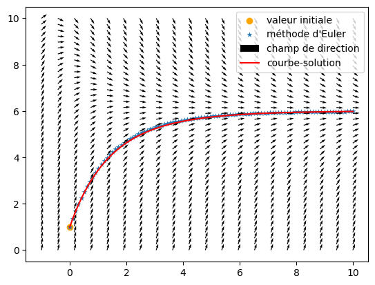

```python
y_sol = lambda t : 6-2*np.exp(-t)-3*np.exp(-t/2)

plt.scatter(0,1, color = "orange", label = "valeur initiale")
plt.scatter(T,Y, marker = "*", linewidths=0.01, label = "méthode d'Euler")
plt.quiver(tt, yy, dt/N, dy/N, label = "champ de direction")
plt.plot(T,y_sol(T), label = "courbe-solution", color = 'red')
plt.legend()
plt.show()
```

### Erreur en fonction du pas :

```python
pas = np.linspace(0.1, 0.001,100)
Err = np.empty(len(pas))


for j,h in enumerate(pas):
    T = np.linspace(0,10,int(10/h))
    Y = np.ones(len(T))
    for i in range(len(T)-1):
        Y[i+1] = Y[i] + y_prime(T[i],Y[i])*(T[i+1]-T[i])

    y_exact = y_sol(T)
    erreur = abs(y_exact - Y)
    Err[j] = sum(erreur)/len(erreur)
```

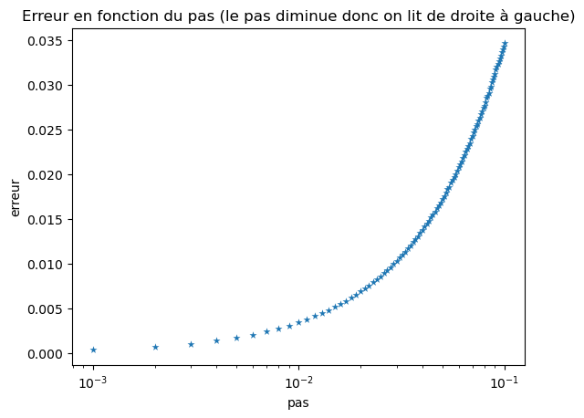

```python
plt.scatter(pas,Err, marker = "*",linewidths=0.01)
plt.xscale("log")
plt.xlabel("pas")
plt.ylabel("erreur")
plt.title("Erreur en fonction du pas (le pas diminue donc on lit de droite à gauche)")
plt.show()
```